# Cancer-prediction

## Predicting whether a mammogram mass is benign or malignant

We'll be using the "mammographic masses" public dataset from the UCI repository (source: https://archive.ics.uci.edu/ml/datasets/Mammographic+Mass)

This data contains 961 instances of masses detected in mammograms, and contains the following attributes:

1. BI-RADS assessment: 1 to 5 (ordinal)
2. Age: patient's age in years (integer)
3. Shape: mass shape: round=1 oval=2 lobular=3 irregular=4 (nominal)
4. Margin: mass margin: circumscribed=1 microlobulated=2 obscured=3 ill-defined=4 spiculated=5 (nominal)
5. Density: mass density high=1 iso=2 low=3 fat-containing=4 (ordinal)
6. Severity: benign=0 or malignant=1 (binominal)

BI-RADS is an assesment of how confident the severity classification is; it is not a "predictive" attribute and so we will ignore it. The age, shape, margin, and density attributes are the features that we will build our model with, and "severity" is the classification we will attempt to predict based on those attributes.

Although "shape" and "margin" are nominal data types, which sklearn typically doesn't deal with well, they are close enough to ordinal that we shouldn't have to discard them. The "shape" for example is ordered increasingly from round to irregular.

In this project, we want to apply several different supervised machine learning techniques to this data set, and see which one yields the highest **precision and recall** on unseen data. In particular, we want to apply the following algorithms:

- Decision tree
- Random forest
- KNN
- Naive Bayes
- SVM
- Logistic Regression

We'll start by importing the libraries we will need in our analysis:

```python
import numpy as np
import pandas as pd
import matplotlib.pyplot as plt
import seaborn as sns

from sklearn.preprocessing import StandardScaler, MinMaxScaler
from sklearn.model_selection import train_test_split
from sklearn.model_selection import cross_validate, cross_val_score

from sklearn.linear_model import LogisticRegression
from sklearn.tree import DecisionTreeClassifier
from sklearn.ensemble import RandomForestClassifier
from sklearn.svm import SVC
from sklearn.neighbors import KNeighborsClassifier
from sklearn.naive_bayes import MultinomialNB
from sklearn.ensemble import VotingClassifier

from sklearn.metrics import accuracy_score
from sklearn.metrics import recall_score
```

## Data preparation

We start by importing the mammographic_masses.data.txt file into a Pandas dataframe and take a look at it. We'll use the optional parameter na_values in read_csv() to convert missing data indicated by a '?' into NaN, and the optional paramter names to add the appropriate column names:

```python
mammograms = pd.read_csv('mammographic_masses.data.txt', header = None,
                         names=['BI-RADS','Age','Shape','Margin','Density','Severity'],
                         na_values = '?')
mammograms.head()
```

|  | BI-RADS | Age | Shape | Margin | Density | Severity |
| --- | --- | --- | --- | --- | --- | --- |
| 0 | 5.0 | 67.0 | 3.0 | 5.0 | 3.0 | 1 |
| 1 | 4.0 | 43.0 | 1.0 | 1.0 | NaN | 1 |
| 2 | 5.0 | 58.0 | 4.0 | 5.0 | 3.0 | 1 |
| 3 | 4.0 | 28.0 | 1.0 | 1.0 | 3.0 | 0 |
| 4 | 5.0 | 74.0 | 1.0 | 5.0 | NaN | 1 |

Let's inspect our data to determine whether or not it needs cleaning.

```python
mammograms.info()
```

```
<class 'pandas.core.frame.DataFrame'>
RangeIndex: 961 entries, 0 to 960
Data columns (total 6 columns):
 #   Column    Non-Null Count  Dtype
---  ------    --------------  -----
 0   BI-RADS   959 non-null    float64
 1   Age       956 non-null    float64
 2   Shape     930 non-null    float64
 3   Margin    913 non-null    float64
 4   Density   885 non-null    float64
 5   Severity  961 non-null    int64
dtypes: float64(5), int64(1)
memory usage: 45.2 KB
```

```python
mammograms.describe()
```

|  | BI-RADS | Age | Shape | Margin | Density | Severity |
| --- | --- | --- | --- | --- | --- | --- |
| count | 959.000000 | 956.000000 | 930.000000 | 913.000000 | 885.000000 | 961.000000 |
| mean | 4.348279 | 55.487448 | 2.721505 | 2.796276 | 2.910734 | 0.463059 |
| std | 1.783031 | 14.480131 | 1.242792 | 1.566546 | 0.380444 | 0.498893 |
| min | 0.000000 | 18.000000 | 1.000000 | 1.000000 | 1.000000 | 0.000000 |
| 25% | 4.000000 | 45.000000 | 2.000000 | 1.000000 | 3.000000 | 0.000000 |
| 50% | 4.000000 | 57.000000 | 3.000000 | 3.000000 | 3.000000 | 0.000000 |
| 75% | 5.000000 | 66.000000 | 4.000000 | 4.000000 | 3.000000 | 1.000000 |
| max | 55.000000 | 96.000000 | 4.000000 | 5.000000 | 4.000000 | 1.000000 |

In order for us to be able to build an accurate model, we need to use accurate data. Therefore, we will go ahead and drop rows with missing data:

```python
mammograms.dropna(axis=0, inplace=True)
```

## EDA

Let's do some exploratory data analysis. We'll start by calculating the correlation matrix to see if there are correlations between the different numerical attributes.

```python
mammograms.corr()
```

|  | BI-RADS | Age | Shape | Margin | Density | Severity |
| --- | --- | --- | --- | --- | --- | --- |
| BI-RADS | 1.000000 | 0.094623 | 0.180120 | 0.157771 | 0.028356 | 0.223826 |
| Age | 0.094623 | 1.000000 | 0.380096 | 0.420913 | 0.052417 | 0.455216 |
| Shape | 0.180120 | 0.380096 | 1.000000 | 0.738014 | 0.073969 | 0.564763 |
| Margin | 0.157771 | 0.420913 | 0.738014 | 1.000000 | 0.124860 | 0.574498 |
| Density | 0.028356 | 0.052417 | 0.073969 | 0.124860 | 1.000000 | 0.068651 |
| Severity | 0.223826 | 0.455216 | 0.564763 | 0.574498 | 0.068651 | 1.000000 |

**Findings**

- All entries in the correlation matrix are positive.
- The strongest correlation is between the Margin and Shape attributes at 0.74
- The next strongest correlations are between Margin and Severity at 0.57, and between Shape and Severity at 0.56.

Let's create a few visualizations to gain a better understanding of our data. First, we'll create two side by side histograms of the Age attribute for the two possible values of the severity:

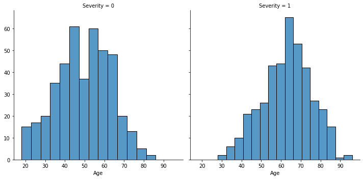

```python
g = sns.FacetGrid(mammograms, col='Severity', height=5, aspect=1)
g.map(sns.histplot, 'Age')
```

**Findings:**

- Breast tumors in younger women (age between 20 and 34) are predominantly benign.
- There are more cases of cancerous breast tumors in women between 55 and 75 years of age than in any other age group.

We now plot side by side histograms of the severity for different values of the shape attribute:

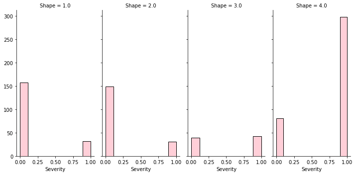

```python
g = sns.FacetGrid(mammograms, col='Shape', height=5, aspect=0.5)
g.map(sns.histplot, 'Severity', color='pink')
```

**Findings:**

Let's draw the same kind of plot using the margin instead of the shape:

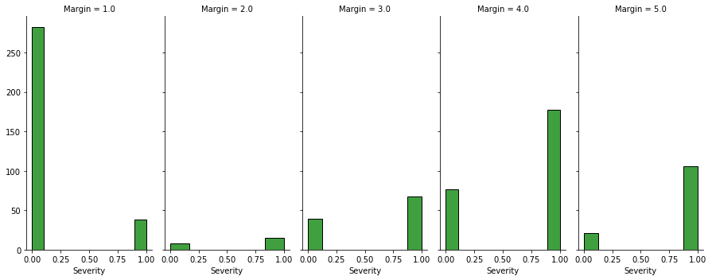

```python
g = sns.FacetGrid(mammograms, col='Margin', height=5, aspect=0.5)
g.map(sns.histplot, 'Severity',color='green')
```

**Findings:**

Finally, let's draw similar histograms using the density:

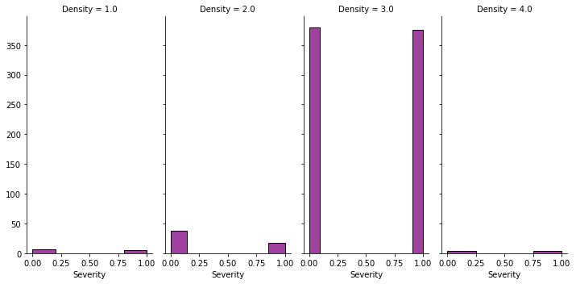

```python
g = sns.FacetGrid(mammograms, col='Density', height=5, aspect=0.5)
g.map(sns.histplot, 'Severity', color='purple')
```

**Findings:**

- No one value of the density seems to indicate a more likely outcome in terms of severity.
- This is confirmed by the very low correlation between density and severity (0.06)

### Feature extraction, train-test split and data normalization

Next we'll create an array that extracts only the feature data we want to work with (age, shape, margin, and density) and another array that contains the labels (severity):

```python
X = mammograms[['Age','Shape','Margin','Density']]
y = mammograms['Severity']
```

We also create training and test sets, setting aside $75\%$ for training and $25\%$ for testing:

```python
X_train, X_test, y_train, y_test = train_test_split(X, y, test_size=0.25, random_state=0)
```

A few of the algorithms we'll be using work best with normalized data, so we shall go ahead and normalize the attribute data of our dataset:

```python
scaler = StandardScaler()
X_train_scaled = scaler.fit_transform(X_train)
X_test_scaled = scaler.fit_transform(X_test)
```

## Decision Trees

Let's create a DecisionTreeClassifier:

```python
dtree = DecisionTreeClassifier()
```

During the training process, we will use K-Fold cross validation (with K=10) to get a more reliable measure of our model's accuracy:

```python
cv_precision = cross_val_score(dtree, X_train, y_train, scoring="precision", cv = 10)
mean_precision = cv_precision.mean()
std_precision = cv_precision.std()


print('Cross-validation results for the precision: ' , cv_precision)
print('\nMean precision of the model: %.2f' % mean_precision)
print('Precision standard deviation: %.2f ' % std_precision)
```

```
Cross-validation results for the precision:  [0.81481481 0.73913043 0.68965517 0.88461538 0.75862069 0.72727273
 0.68421053 0.79411765 0.86363636 0.74074074]

Mean precision of the model: 0.77
Precision standard deviation: 0.06
```

```python
cv_recall = cross_val_score(dtree, X_train, y_train, scoring="recall", cv = 10)
mean_recall = cv_recall.mean()
std_recall = cv_recall.std()


print('Cross-validation results for recall: ' , cv_recall)
print('\nMean recall: %.2f' % mean_recall)
print('Recall standard deviation: %.2f ' % std_recall)
```

```
Cross-validation results for recall:  [0.70967742 0.5483871  0.63333333 0.73333333 0.73333333 0.83333333
 0.83870968 0.87096774 0.61290323 0.64516129]

Mean recall: 0.72
Recall standard deviation: 0.10
```

Let us create a custom function to display the precision and recall along with the associated standard deviations in the form of a dataframe:

```python
def print_precision_recall(model, X_train, y_train):
    model_precision = cross_val_score(model, X_train, y_train, scoring="precision", cv = 10)
    mean_precision = cv_precision.mean()
    std_precision = cv_precision.std()

    model_recall = cross_val_score(model, X_train, y_train, scoring="recall", cv = 10)
    mean_recall = model_recall.mean()
    std_recall = model_recall.std()

    df = pd.DataFrame({'precision':[mean_precision,std_precision], 'recall':[mean_recall,std_recall]},\
                     index=['mean', 'std'])
    return df
```

Let us use this custom function to find the precision and recall of the decision tree model:

```python
print_precision_recall(dtree, X_train, y_train)
```

|  | precision | recall |
| --- | --- | --- |
| mean | 0.769681 | 0.715914 |
| std | 0.064864 | 0.099805 |

## Random Forest

Let' see if we can do better with a RandomForestClassifier.

```python
rforest = RandomForestClassifier()
```

We'll use a 10 fold cross-validation again:

```python
print_precision_recall(rforest, X_train, y_train)
```

|  | precision | recall |
| --- | --- | --- |
| mean | 0.769681 | 0.768495 |
| std | 0.064864 | 0.095796 |

## SVM

Next, we want to use svm.SVC with a linear kernel. Note that we are fitting our model on the scaled features X_train_scaled:

```python
svm = SVC(kernel='linear')
```

```python
print_precision_recall(svm, X_train_scaled, y_train)
```

|  | precision | recall |
| --- | --- | --- |
| mean | 0.769681 | 0.882473 |
| std | 0.064864 | 0.076640 |

The recall has now jumped to 0.88, which is great news, even though the precision is still about the same.

## KNN

How about K-Nearest-Neighbors?

K is an hyperparameter that needs to be tuned. Let's write a for loop to run KNN with K values ranging from 1 to 50 and make a note of the value of K that results in the best performance of our model (note that we are again using scaled features):

```python
Kmax = 50
KNN_scores = list()
for K in range(1,50):
    knn = KNeighborsClassifier(n_neighbors = K)

    knn_precision = cross_val_score(knn, X_train_scaled, y_train, scoring="precision", cv = 10).mean()

    KNN_scores.append(knn_precision)

max_score = max(KNN_scores)
print(max_score)
```

```
0.7929393145284005
```

Here is the value of K corresponding to max_score:

```python
best_K = 1 + KNN_scores.index(max_score)
print(best_K)
```

```
4
```

```python
knn = KNeighborsClassifier(n_neighbors = best_K)
```

```python
print_precision_recall(knn, X_train, y_train)
```

|  | precision | recall |
| --- | --- | --- |
| mean | 0.769681 | 0.745591 |
| std | 0.064864 | 0.083086 |

## Naive Bayes

Now we'll try naive_bayes.MultinomialNB. How does its accuracy stack up?

Note that we'll need to use MinMaxScaler to get the features in the range MultinomialNB requires.

```python
scaler = MinMaxScaler()

X_train_scaled = scaler.fit_transform(X_train)
X_test_scaled = scaler.fit_transform(X_test)
```

```python
nb = MultinomialNB()
```

```python
print_precision_recall(nb, X_train_scaled, y_train)
```

|  | precision | recall |
| --- | --- | --- |
| mean | 0.769681 | 0.853441 |
| std | 0.064864 | 0.073298 |

The naive Bayes algorithm gives a good value of the recall, but the precision is still unchanged at around 0.76.

## Revisiting SVM

svm.SVC may perform differently with different kernels. The choice of kernel is an example of a "hyperparamter." Here, we want to try the rbf, sigmoid, and poly kernels and see what the best-performing kernel is.

### Radial Basis Functions kernel

```python
svm_rbf = SVC(kernel='rbf')
```

```python
print_precision_recall(svm_rbf, X_train_scaled, y_train)
```

|  | precision | recall |
| --- | --- | --- |
| mean | 0.769681 | 0.892366 |
| std | 0.064864 | 0.073587 |

This is the best value of recall so far at 0.89. The precision is still hovering around the 0.76 mark.

### Sigmoid kernel

```python
svm_sigmoid = SVC(kernel='sigmoid')
```

```python
print_precision_recall(svm_sigmoid, X_train_scaled, y_train)
```

|  | precision | recall |
| --- | --- | --- |
| mean | 0.769681 | 0.228602 |
| std | 0.064864 | 0.045144 |

Sigmoid kernel has a very small recall of 0.23.

### Polynomial kernel

```python
svm_poly = SVC(kernel='poly', degree=3, coef0=1, C=5)
```

```python
print_precision_recall(svm_poly, X_train_scaled, y_train)
```

|  | precision | recall |
| --- | --- | --- |
| mean | 0.769681 | 0.869677 |
| std | 0.064864 | 0.095492 |

Polynomial kernel with the parameters shown has a good recall at 0.86. The precision is again around 0.76.

## Logistic Regression

We've tried all these fancy techniques, but fundamentally this is just a binary classification problem. Let's try Logisitic Regression, which is a simple way to tackling this sort of thing.

```python
log_reg = LogisticRegression()
```

```python
print_precision_recall(log_reg, X_train, y_train)
```

|  | precision | recall |
| --- | --- | --- |
| mean | 0.769681 | 0.849892 |
| std | 0.064864 | 0.089210 |

Logistic regression has a good recall value of 0.85, but the precision is the same as all other algorithms at 0.76.

## Majority Voting Ensemble

Let's try a majority voting ensemble where we combine results from various classifiers: the label assigned to a given data point is determined as the most frequent label predicted by these classifiers (hard voting). We'll choose the following models:

- SVM with linear kernel
- SVM with polynomial kernel
- SVM with radial basis functions kernel
- Naive Bayes.
- Logistic regression

We'll start by creating a list of tuples called models, where each tuple contains a label for the classifier (a string) and the classifier itself. Then, we'll feed this list of models to the VotingClassifier() class from sklearn and fit to the training data.

```python
# Create an empty list
models = list()

# Add the models one by one to the list
models.append(('svm-lin', SVC(kernel='linear')))
models.append(('svm-poly', SVC(kernel='poly', degree=3, coef0=1, C=5)))
models.append(('svm-rbf', SVC(kernel='rbf')))
models.append(('nb', MultinomialNB()))
models.append(('logreg', LogisticRegression()))

# Define the hard voting ensemble
ensemble = VotingClassifier(estimators=models, voting='hard')

# Fit the model on the training data
ensemble.fit(X_train, y_train)

# Print the precision and recall of the hard voting ensemble
print('Precision of the majority voting ensemble %.2f' % cross_val_score(ensemble, X_train, y_train, scoring="precision", cv = 10).mean())
print('\nRecall of the majority voting ensemble %.2f' % cross_val_score(ensemble, X_train, y_train, scoring="recall", cv = 10).mean())
```

```
Precision of the majority voting ensemble 0.77

Recall of the majority voting ensemble 0.88
```

## Minority Voting Ensemble

For a problem like cancer detection, the recall metric is of particular importance. From its definition:

\begin{equation} Recall = \frac{\mbox{True positive rate}}{\mbox{True positive rate} + \mbox{False negative rate}} \end{equation}

we see that a classifier with recall close to unity implies that the false negative rate is much smaller than the true positive rate, which is a very desirable feature to have in a classification model. A false negative rate close to zero means that not too many cancerous tumors are classified as benign. That's where the idea of minority voting ensemble comes into play: we will label a tumor as severe as soon as one of the classifiers labels it as such, even if all the other classifiers label this particular tumor as benign. Proceeding in this way, we hope to be able to catch as many cancerous tumors as we can, without too much affecting the precision of the model. In fact, it is not difficult to see that the precision of the minority voting ensemble is at least as good as the lowest precision of the individual classifiers chosen.

```python
# y_pred is a dictionary built from the list of models defined above. It stores the following data:
# y_pred.keys() are strings that we use to label the classifiers
# y_pred.values() are the actual models

y_pred = dict()
for model in models:
    # fit the model to the training data
    model[1].fit(X_train, y_train)

    # predict the values of the labels for X_train and store in y_pred
    y_pred[model[0]] = model[1].predict(X_train)
```

```python
# Here we construct a dataframe to nicely display
# the predicted training labels for each classifier
predictions_dict = dict()
for model in models:
    model_name = model[0]
    predictions_dict[model_name] = y_pred[model_name]

predictions_df = pd.DataFrame(predictions_dict)
predictions_df.head()
```

|  | svm-lin | svm-poly | svm-rbf | nb | logreg |
| --- | --- | --- | --- | --- | --- |
| 0 | 0 | 0 | 0 | 0 | 0 |
| 1 | 1 | 1 | 1 | 1 | 1 |
| 2 | 1 | 1 | 1 | 1 | 1 |
| 3 | 0 | 0 | 0 | 0 | 0 |
| 4 | 1 | 1 | 1 | 1 | 1 |

We now create a column called "Minority vote" where we add the results of the 5 classifiers:

```python
predictions_df['Minority vote'] = predictions_df.sum(axis=1)
predictions_df.head()
```

|  | svm-lin | svm-poly | svm-rbf | nb | logreg | Minority vote |
| --- | --- | --- | --- | --- | --- | --- |
| 0 | 0 | 0 | 0 | 0 | 0 | 0 |
| 1 | 1 | 1 | 1 | 1 | 1 | 5 |
| 2 | 1 | 1 | 1 | 1 | 1 | 5 |
| 3 | 0 | 0 | 0 | 0 | 0 | 0 |
| 4 | 1 | 1 | 1 | 1 | 1 | 5 |

We then adjust the minority vote label to be 1 for any nonzero value (1, 2, 3, 4 or 5): a tumor is declared to be cancerous as soon as one of the classifiers determines as much. A corollary of this is that a tumor will be declared to be benign if and only if all the classifiers find it to be benign.

```python
predictions_df['Minority vote'] = predictions_df['Minority vote'].apply(lambda x: 1 if x>0 else 0)
predictions_df.head()
```

|  | svm-lin | svm-poly | svm-rbf | nb | logreg | Minority vote |
| --- | --- | --- | --- | --- | --- | --- |
| 0 | 0 | 0 | 0 | 0 | 0 | 0 |
| 1 | 1 | 1 | 1 | 1 | 1 | 1 |
| 2 | 1 | 1 | 1 | 1 | 1 | 1 |
| 3 | 0 | 0 | 0 | 0 | 0 | 0 |
| 4 | 1 | 1 | 1 | 1 | 1 | 1 |

Now we are ready to find the precision and recall of our minority voting model:

```python
y_minority = predictions_df['Minority vote']
print('Minority vote precision: %.2f' % accuracy_score(y_train, y_minority))
print('Minority vote recall: %.2f' % recall_score(y_train, y_minority))
```

```
Minority vote precision: 0.76
Minority vote recall: 0.93
```

While the precision has remained the same as for each individual classifier chosen, the recall has significantly improved, which is a very good thing. Time to check if this improvement will hold on the test set.

## Measuring the performance on the test set:

We will follow the exact same steps as above so we won't be commenting on each step:

```python
y_test_pred = dict()
for model in models:
    # predict the values of the labels for X_train and store in y_pred
    y_test_pred[model[0]] = model[1].predict(X_test)
```

```python
test_predictions_dict = dict()
for model in models:
    model_name = model[0]
    test_predictions_dict[model_name] = y_test_pred[model_name]

test_predictions_df = pd.DataFrame(test_predictions_dict)
test_predictions_df.head()
```

|  | svm-lin | svm-poly | svm-rbf | nb | logreg |
| --- | --- | --- | --- | --- | --- |
| 0 | 1 | 1 | 1 | 1 | 1 |
| 1 | 0 | 0 | 1 | 0 | 0 |
| 2 | 1 | 1 | 1 | 1 | 1 |
| 3 | 0 | 0 | 0 | 0 | 0 |
| 4 | 0 | 0 | 0 | 1 | 0 |

```python
test_predictions_df['Minority vote'] = test_predictions_df.sum(axis=1)
test_predictions_df['Minority vote'] = test_predictions_df['Minority vote'].apply(lambda x: 1 if x>0 else 0)
test_predictions_df.head()
```

|  | svm-lin | svm-poly | svm-rbf | nb | logreg | Minority vote |
| --- | --- | --- | --- | --- | --- | --- |
| 0 | 1 | 1 | 1 | 1 | 1 | 1 |
| 1 | 0 | 0 | 1 | 0 | 0 | 1 |
| 2 | 1 | 1 | 1 | 1 | 1 | 1 |
| 3 | 0 | 0 | 0 | 0 | 0 | 0 |
| 4 | 0 | 0 | 0 | 1 | 0 | 1 |

```python
y_test_minority = test_predictions_df['Minority vote']
print('Minority vote precision: %.2f' % accuracy_score(y_test, y_test_minority))
print('Minority vote recall: %.2f' % recall_score(y_test, y_test_minority))
```

```
Minority vote precision: 0.75
Minority vote recall: 0.94
```

Hooray! The training results are validated by the test set.

## Conclusion:

We have applied various classification algorithms to the mammographic masses data set from the public repository at UC Irvine. Using a minority voting ensemble we were able to improve the recall metric from values around 85-88% for single classifiers to values around 94% on the test set. This is just a first exploration of the idea of minority voting ensemble. This idea should be further analyzed and refined in the future to gain a better understanding of its strengths and limitations.